# Лабораторная работа №1

Лабораторная работа №1 посвящена основам квантовой механики: принцип неопределенности Гейзенберга, уравнение Шредингера, электронные конфигурации атомов и молекул, правила Клечковского и Хунда, а также запрет Паули.

## 1. Принцип неопределенности Гейзенберга

Принцип **неопределённости Гейзенбе́рга** в квантовой механике - фундаментальное соображение (соотношение неопределённостей), устанавливающее предел точности одновременного определения пары характеризующих систему квантовых наблюдаемых, описываемых некоммутирующими операторами (например, координаты и импульса). Более доступно он звучит так: **чем точнее измеряется одна характеристика частицы, тем менее точно можно измерить вторую.** Принцип неопределённости, открытый Вернером Гейзенбергом в 1927 г., является одним из краеугольных камней физической квантовой механики.

Если имеется несколько (много) идентичных копий системы в данном состоянии, то измеренные значения координаты и импульса будут подчиняться определённому распределению вероятности — это фундаментальный постулат квантовой механики. Измеряя величину среднеквадратического отклонения $\Delta x$ координаты и среднеквадратического отклонения $\Delta p$ импульса, мы найдём, что $$ \Delta x\Delta p\geqslant {\frac {\hbar }{2}}, $$ где $\hbar$ — приведённая постоянная Планка.

## 2. Уравнение Шредингера

**В классической механике** состояние частицы описывается заданием координаты $\vec r(t_0)$ и импульса $\vec p(t_0)$ в некоторый момент времени $t_0$. Дальнейшее движение частицы в потенциальном поле $U(\vec r)$ происходит согласно уравнениям движения - уравнениям Гамильтона: $$ \frac{d\vec r}{dt} = \frac{\partial H}{\partial \vec p}, \frac{d\vec p}{dt} = - \frac{\partial H}{\partial \vec r}, $$ где $$ H(\vec r, \vec p) = \frac{\vec p^2}{2m} + U(\vec r) $$ - функция Гамильтона.

**В квантовой механике** принципиально изменяется понятие состояния частицы уже потому, что у волны нет траектории и задать одновременно коородинату и импульс невозможно. Описание волновых свойств частицы в некоторый момент времени $t_0$ дается волновой функцией $\Psi(\vec r, t_0)$. Изменение этой функции со временем происходит согласно уравнению Шредингера: $$ i\hbar\frac{\partial \Psi(\vec r, t)}{\partial t} = \left(-\frac{\hbar^2}{2m}\triangle + U(\vec r)\right)\Psi(\vec r, t). $$ Связь такого описания с экспериментом дается следующим постулатом: **квадрат модуля волновой функции пропорционален плотности вероятности**, т.е. вероятность $dW(\vec r)$ найти частицу в объеме $dV$ есть $$ dW(\vec r) \propto |\Psi(\vec r, t)|^2 dV. $$

Для примера рассмотрим, как ведет себя частица в коробке. Проблема частиц в коробке не соответствует какой-либо реальной химической системе. Его полезность в нашем контексте заключается в том, что он иллюстрирует некоторые квантово-механические особенности. Потенциальная энергия на барьере установлена на бесконечность (т.е. частица не может вырваться), а потенциальная энергия внутри барьера установлена на 0. В этих условиях классическая механика предсказывает, что частица имеет равную вероятность нахождения в любой части коробка и кинетическая энергия частицы могут иметь любое значение. Принимая это предположение во внимание, мы получаем различные уравнения для энергии частицы на барьере и внутри коробки.

На барьере $U$ бесконечно и, следовательно, частица не существует. Внутри коробки $U$ равно нулю и, следовательно, волна может иметь любое конечное значение: $$ \phi '' + \frac{8mE}{\hbar^2}\phi = 0. $$ Волновая функция должна быть такой, чтобы при двукратном дифференцировании она давала ту же функцию, умноженную на $E$. Функция синуса обладает таким поведением. Также добавим граничные условия: волновые функции на барьерах равны нулю и нормировка на единицу. Ответ: $$ E_n = \frac{n^2 h^2}{8mL^2}, $$ $$ \phi_n = \left(\frac{2}{L}\right)^{0.5} sin\frac{\pi n x}{L}. $$

```python
import numpy as np
import holoviews as hv
hv.extension('bokeh')

%output size=60 dpi=100
%opts Curve [aspect=3 show_grid=True] (line_width=2)

h = 6.63e-34
m = 9.11e-31
n_list = [i for i in range(1, 5+1)]
L = 1

dim_x  = hv.Dimension('x',  unit='m', range=(0, L))
dim_psi  = hv.Dimension('|Ψ*Ψ|')

def sine_curve(n, L):
    x_list =  [0.01*i for i in range(L*100)]
    return hv.Curve((x_list, [np.square(np.sqrt(2/L)*np.sin(n*np.pi*x/L)) for x in x_list]), kdims=dim_x, vdims=dim_psi)

curve_dict = {n:sine_curve(n,L) for n in n_list}

hmap = hv.HoloMap(curve_dict, kdims='n')
hmap
```

[interactive chart not shown]

Из-за своей математической простоты, модель частицы в ящике используется для поиска приближенных решений для более сложных физических систем, в которых частица находится в узкой области с низким электрическим потенциалом между двумя высокими потенциальными барьерами. Эти системы с квантовыми ямами особенно важны в оптоэлектронике и используются в таких устройствах, как лазер с квантовыми ямами, инфракрасный фотодетектор с квантовыми ямами и модулятор квантово-ограниченного эффекта Штарка . Он также используется для моделирования решетки в модели Кронига-Пенни и для конечного металла в приближении свободных электронов.

## 3. Квантовые числа

Квантовое число в квантовой механике — численное значение какой-либо квантованной переменной микроскопического объекта (элементарной частицы, ядра, атома и т. д.), характеризующее состояние этого объекта. Задание всех квантовых чисел однозначно и полностью характеризует состояние частицы.

Например, состояние электрона в атоме и вид описывающей его волновой функции могут быть охарактеризованы четырьмя квантовыми числами: главным ($n$), орбитальным ($l$), магнитным ($m$) и спиновым ($s$}.

**Главное квантовое число** ($n$) — целое число, для водорода и водородоподобных атомов определяет возможные значения энергии. Главное квантовое число обозначается как $n$. Исторически энергетическим уровням атомов были приписаны обозначения $K, L, M, N, O, P, Q$. Эти обозначения используются параллельно с указанием значений главного квантового числа $n$. Так, $K$-оболочкой называется энергетический уровень, для которого $n=1$, $L$-оболочкой — энергетический уровень с $n=2$ и т.д.

**Орбитальное (побочное или азимутальное) квантовое число** ($l$) — в квантовой физике квантовое число $l$, определяющее форму распределения амплитуды волновой функции электрона в атоме, то есть форму электронного облака. Характеризует число плоских узловых поверхностей. Определяет подуровень энергетического уровня, задаваемого главным (радиальным) квантовым числом $n$ и может принимать значения:

$$ l ={0;1;2;...;n-1}. $$

Каждому значению $l$ соответствует орбиталь особой формы. При $l=0$ атомная орбиталь независимо от значения главного квантового числа имеет сферическую форму ($s$-орбиталь). Значению $l=1$ соответствует атомная орбиталь, имеющая форму гантели ($p$-орбиталь). Ещё более сложную форму имеют орбитали, отвечающие высоким значениям $l$.

**Магнитное квантовое число** ($m$) — квантовое число, параметр, который вводится при решении уравнения Шрёдингера для электрона в водородоподобном атоме (и вообще для любого движения заряженной частицы). Магнитное квантовое число характеризует ориентацию в пространстве орбитального момента импульса электрона или пространственное расположение атомной орбитали. Оно принимает целые значения от $-l$ до $+l$, где $l$ — орбитальное квантовое число, то есть имеет ровно столько значений, сколько орбиталей существует на каждом подуровне.

**Спиновое квантовое число** ($s$) характеризует магнитный момент, возникающий при вращении электрона вокруг своей оси. Принимает только два значения $+1/2$ и $-1/2$ соответствующие противоположным направлениям вращения.

Рассмотрим волновое уравнение относительно квантовых чисел, оно может быть в следующем трехмерном формате: $$ \phi_{n,l,m}(r, \theta, \phi) = R_{n,l}(r) Y_{l,m}(\theta, \phi). $$ Теперь разделение переменных зависит от типа атома и является слишком сложным. Вместо этого мы просто напишем решение непосредственно для построения графика $Y_{l,m}(\theta, \phi)$.

```
0 0
1 -1
1 0
1 1
2 -2
2 -1
2 0
2 1
2 2
```

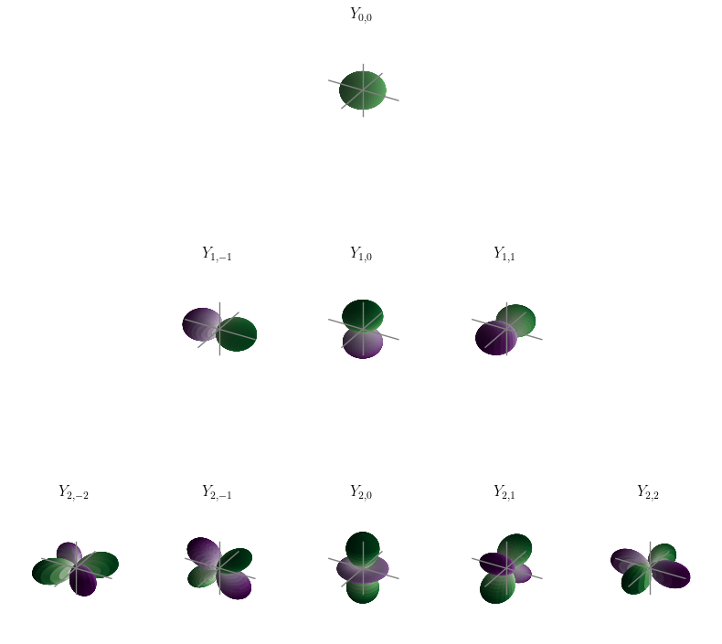

```python
import numpy as np
import matplotlib.pyplot as plt
import matplotlib.gridspec as gridspec
# The following import configures Matplotlib for 3D plotting.
from mpl_toolkits.mplot3d import Axes3D
from scipy.special import sph_harm
plt.rc('text', usetex=True)

# Grids of polar and azimuthal angles
theta = np.linspace(0, np.pi, 100)
phi = np.linspace(0, 2*np.pi, 100)
# Create a 2-D meshgrid of (theta, phi) angles.
theta, phi = np.meshgrid(theta, phi)
# Calculate the Cartesian coordinates of each point in the mesh.
xyz = np.array([np.sin(theta) * np.sin(phi),
                np.sin(theta) * np.cos(phi),
                np.cos(theta)])

def plot_Y(ax, el, m):
    """Plot the spherical harmonic of degree el and order m on Axes ax."""

    # NB In SciPy's sph_harm function the azimuthal coordinate, theta,
    # comes before the polar coordinate, phi.
    Y = sph_harm(abs(m), el, phi, theta)

    # Linear combination of Y_l,m and Y_l,-m to create the real form.
    if m < 0:
        Y = np.sqrt(2) * (-1)**m * Y.imag
    elif m > 0:
        Y = np.sqrt(2) * (-1)**m * Y.real
    Yx, Yy, Yz = np.abs(Y) * xyz

    # Colour the plotted surface according to the sign of Y.
    cmap = plt.cm.ScalarMappable(cmap=plt.get_cmap('PRGn'))
    cmap.set_clim(-0.5, 0.5)

    ax.plot_surface(Yx, Yy, Yz,
                    facecolors=cmap.to_rgba(Y.real),
                    rstride=2, cstride=2)

    # Draw a set of x, y, z axes for reference.
    ax_lim = 0.5
    ax.plot([-ax_lim, ax_lim], [0,0], [0,0], c='0.5', lw=1, zorder=10)
    ax.plot([0,0], [-ax_lim, ax_lim], [0,0], c='0.5', lw=1, zorder=10)
    ax.plot([0,0], [0,0], [-ax_lim, ax_lim], c='0.5', lw=1, zorder=10)
    # Set the Axes limits and title, turn off the Axes frame.
    ax.set_title(r'$Y_{{{},{}}}$'.format(el, m))
    ax_lim = 0.5
    ax.set_xlim(-ax_lim, ax_lim)
    ax.set_ylim(-ax_lim, ax_lim)
    ax.set_zlim(-ax_lim, ax_lim)
    ax.axis('off')

el_max = 2
figsize_px, DPI = 800, 100
figsize_in = figsize_px / DPI
fig = plt.figure(figsize=(figsize_in, figsize_in), dpi=DPI)
spec = gridspec.GridSpec(ncols=2*el_max+1, nrows=el_max+1, figure=fig)
for el in range(el_max+1):
    for m_el in range(-el, el+1):
        print(el, m_el)
        ax = fig.add_subplot(spec[el, m_el+el_max], projection='3d')
        plot_Y(ax, el, m_el)
plt.tight_layout()
plt.savefig('sph_harm.png')
plt.show()
```

## 4. Электронная кофигурация. Энергия распределения электронов.

Существует условное изображение электронных уровней и подуровней, называемое орбитальной диаграммой. На такой диаграмме орбитали условно изображаются квадратиками, а электроны - стрелочками. Если стрелочки направлены в разные стороны, это означает, что электроны различаются между собой особым свойством, которое назывется спином электрона. В данный момент для нас не важна суть этого свойства. Требуется лишь понимать, что электроны могут чем-то отличаться друг от друга.

Рассмотрим атом лития. У него три протона в ядре, поэтому литий содержит в своем электронном облаке 3 электрона, для чего занимает электронами сначала весь 1-й уровень (там помещается только 2 электрона), а оставшийся электрон вынужден переместиться на более высокий 2-й уровень, где займет ближайшую к ядру свободную $2s$-орбиталь. "Адрес" трех электронов этого элемента таков: $1s^22s^1$. Мы записали электронную формулу для лития.

Из этих простых примеров становится ясен **принцип минимума энергии - при заполнении электронных оболочек в первую очередь заполняются более низкие, ближайшие к ядру уровни и подуровни.**

Чем дальше от ядра располагаются уровни и подуровни, тем выше их энергия. Для атомов, у которых мало электронов (например, $3Li$) уровни и подуровни распределяются по энергии вполне логично: $1s$, затем $2s, 2p$, затем $3s, 3p, 3d$, затем $4s, 4p, 4d, 4f …$ и т.д. Правда, об этом редко вспоминают, потому что у «легких» атомов 3-й и 4-й уровни пусты. Но с возрастанием числа электронов в многоэлектронных атомах все электроны начинают заметно взаимодействовать не только с ядром, но и друг с другом. В частности, электроны нижних уровней «заслоняют» электроны верхних уровней от влияния ядра (в физике это называется экранированием). Чем дальше от ядра, тем меньше становится разница между соседними уровнями и подуровнями. В результате некоторые верхние подуровни начинают «наезжать» друг на друга.

Как нам уже известно, атом каждого элемента содержит строго определенное число электронов, равное числу протонов в его ядре (то есть заряду ядра). Правила заполнения электронных оболочек следующие:

1. Сначала выясняем, сколько всего электронов содержит атом интересующего нас элемента. Для этого достаточно знать заряд его ядра, который всегда равен порядковому номеру элемента в Периодической таблице Д.И.Менделеева. Порядковый номер (число протонов в ядре) в точности равен и числу электронов во всем атоме.
2. Последовательно заполняем орбитали, начиная с нижней $1s$-орбитали, имеющимися электронами. При этом нельзя располагать на каждой орбитали более двух электронов.
3. Записываем электронную формулу элемента.

Электронная формула описывает распределение электронов по энергетическим уровням, существующим в электронном облаке. Такое распределение называется также электронной конфигурацией атома.

## 5. Принцип запрета Паули

Как мы видим, каждый электрон в атоме имеет свой собственный "адрес", записанный набором из четырех квантовых чисел. Например, если два электрона находятся на одном и том же уровне (имеют одинаковое число $n$), и даже на одном подуровне (например, $p$-подуровне), то они обязательно расположатся на разных орбиталях - то есть будут отличаться числом $m$. А если орбитали уже полностью заполнены, то два находящиеся на них электрона обязательно должны отличаться друг от друга спиновым квантовым числом $s$. Таким образом, теперь мы можем дать строгую формулировку **принципа** или **запрета Паули**: **Никакие два электрона в одном атоме не могут характеризоваться одинаковым набором всех четырех квантовых чисел $n, l, m, s$.**

## 6. Правило Клечковского

Порядок заполнения уровней и подуровней в вполне логичный: $1s, 2s, 2p, 3s, 3p, 3d, 4s$ … . Как показали спектры испускания, это характерно только для атомов c небольшим числом электронов. Впрочем, об этом редко вспоминают, потому что у самых легких элементов на 3-м и 4-м уровнях вообще нет электронов. С увеличением числа электронов в атоме подуровень $4s$, как мы уже знаем, начинает заполняться раньше, чем $3d$. А на более высоких уровнях такие "нарушения" становятся правилом. Можно воспользоваться уже освоенными нами квантовыми числами для того, чтобы уметь воспроизводить ряд заполнения электронами уровней и подуровней большинства атомов $(1s, 2s, 2p, 3s, 3p, 4s, 3d, 4p, 5s, 4d, 5p, 6s, 4f, 5d, 6p, 7s, 5f, 6d …)$ с помощью **правила Клечковского**: **Энергия уровней и подуровней возрастает в порядке увеличения суммы $n + l$, а при одном и том же значении этой суммы ниже располагаются уровни с меньшим $n$.**

Но на практике гораздо легче не мучиться со сложением квантовых чисел, а использовать для реконструкции этого ряда схему длинной формы [Периодической таблицы](http://www.hemi.nsu.ru/135.jpg).

## 7. Правило Хунда

Существует правило (оно называется *правилом Хунда*), по которому электроны предпочитают расселяться на одинаковых по энергии орбиталях (например, на трех $p$-орбиталях) сначала по одиночке, и лишь когда в каждой такой орбитали уже находится по одному электрону, начинается заполнение этих орбиталей вторыми электронами. Когда орбиталь заселяется двумя электронами, такие электроны называют *спаренными*. Объясняют это тем, что в соседних ячейках электроны меньше отталкиваются друг от друга, как одноименно заряженные частицы.

**По правилу Хунда при заполнении электронами одинаковых по энергии орбиталей электроны располагаются в первую очередь по одиночке на каждой орбитали, и лишь потом начинается заселение этих орбиталей вторыми электронами.**

## 8. Электронная конфигурация элементов: N, P, K, Ca, Ti, Zn

Азот (**N**) – седьмой по счету элемент Периодической таблицы. Относится к неметаллам. Расположен во втором периоде V группы A подгруппы. Заряд ядра равен +7.

Атом азота имеет две оболочки, как и все элементы, расположенные во втором периоде. Номер группы –V – свидетельствует о том, что на внешнем электронном уровне атома азота находится 5 валентных электронов.

Электронная конфигурация основного состояния записывается следующим образом:

$$ 1s^22s^22p^3. $$

Электронная конфигурация основного состояния записывается следующим образом:

$$ 1s^22s^22p^63s^23p^3. $$

Калий (**K**) – первый элемент четвертого периода. Он расположен в I группе главной (А) подгруппе Периодической таблицы. Относится к элементам $s$ — семейства. Металл. Элементы-металлы, входящие в эту группу, носят общее название щелочных. Порядковый номер – 19.

Атом калия состоит из положительно заряженного ядра (+19), внутри которого есть 19 протонов и 20 нейтронов, а вокруг, по 4-м орбитам движутся 19 электронов.

Распределение электронов по орбиталям выглядит следующим образом: $$ 1s^22s^22p^63s^23p^64s^1. $$

Кальций (**Ca**) –элемент четвертого периода II группы главной (А) подгруппы Периодической таблицы. Относится к элементам $s$ — семейства. Металл. Элементы-металлы, входящие в эту группу, носят общее название щелочно-земельных. Порядковый номер – 20.

Атом кальция состоит из положительно заряженного ядра (+20), внутри которого есть 20 протонов и 20 нейтронов, а вокруг, по четырем орбитам движутся 20 электронов.

Распределение электронов по орбиталям выглядит следующим образом: $$ 1s^22s^22p^63s^23p^64s^2. $$

Титан (**Ti**) расположен в четвертом периоде IV группы побочной (B) подгруппы Периодической таблицы. Относится к элементам $d$ — семейства. Металл. Порядковый номер – 22.

Атом титана состоит из положительно заряженного ядра (+22), внутри которого есть 22 протона и 26 нейтронов, а вокруг, по четырем орбитам движутся 22 электрона.

Распределение электронов по орбиталям выглядит следующим образом: $$ 1s^22s^22p^63s^23p^63d^24s^2. $$

Цинк (**Zn**) — элемент четвертого периода II группы побочной (B) подгруппы Периодической таблицы. Относится к элементам $d$ — семейства. Металл. Порядковый номер – 30.

Атом цинка состоит из положительно заряженного ядра (+30), внутри которого есть 30 протонов и 35 нейтронов, а вокруг, по четырем орбитам движутся 30 электронов.

Распределение электронов по орбиталям выглядит следующим образом: $$ 1s^22s^22p^63s^23p^63d^{10}4s^2. $$

#### *Спасибо за внимание!*